# MachineLearningProject

Hichem

22/07/2020

## introduction

Using devices such as Jawbone Up, Nike FuelBand, and Fitbit it is now possible to collect a large amount of data about personal activity relatively inexpensively. These type of devices are part of the quantified self movement – a group of enthusiasts who take measurements about themselves regularly to improve their health, to find patterns in their behavior, or because they are tech geeks. One thing that people regularly do is quantify how much of a particular activity they do, but they rarely quantify how well they do it. In this project, our goal will be to use data from accelerometers on the belt, forearm, arm, and dumbell of 6 participants. They were asked to perform barbell lifts correctly and incorrectly in 5 different ways

## load the data

```r
train_data <- read.csv(url("https://d396qusza40orc.cloudfront.net/predmachlearn/pml-training.csv"))
test_data <- read.csv("pml-testing.csv")
dim(train_data)
```

```
## [1] 19622   160
```

## data cleanning :

we notice that there’s 160 columns but after checking each column we notice that some columns has so many null values. we will delete the columns that has more than 90% of null values after we will remove the first columns (X , user_name , raw_timestamp_part_1 , raw_timestamp_part_2 , cvtd_timestamp) cause they are not usefull for our model in the end of this step we will create a new data set in which we will consider only the variables that can be used as predictors

```r
library(dplyr)
EmptyCol <- which(colSums(is.na(train_data) | train_data == "") > 0.9 * dim(train_data)[1])
train_data <- train_data[ , -EmptyCol]
train_data <- train_data[ , -c(1:7)]
dim(train_data)
```

```
## [1] 19622    53
```

## data exploration

first we will see how many observation we have for each class

```r
table(train_data$classe)
```

```
##
##    A    B    C    D    E
## 5580 3797 3422 3216 3607
```

there’s five classes, which are pretty much balanced

next we will check the correlation between the variables :

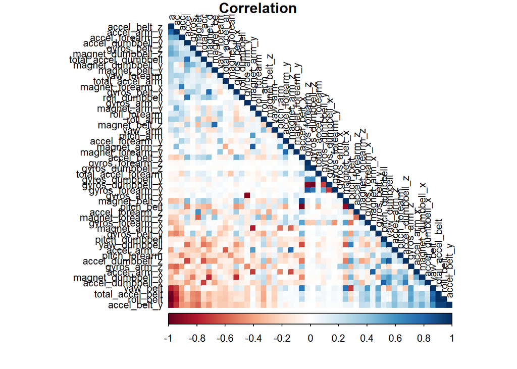

```r
library(corrplot)
corMatrix <- cor(train_data[ , -53])
corrplot(corMatrix , order = "FPC" , method = "color" , type = "lower" ,
         tl.cex = 0.8 , tl.col = rgb(0,0,0) , mar = c(1,1,1,1) , title = "Correlation")
```

we notice that there’s a lot of blue and red boxes which means a strong correlation between the variables. Let’s check how many pair of variables that have a corelation greater then 0.8

```r
c <- abs(corMatrix)
diag(c) <- 0
c <- which(c > 0.8 , arr.ind = TRUE)
c <- dim(c)[1]
c
```

```
## [1] 38
```

```r
library(dplyr)
library(caret)

train_index <- createDataPartition(train_data$classe , p = 0.65 , list = FALSE)
train <- train_data[train_index , ]
validation <- train_data[-train_index , ]
dim(train)
```

```
## [1] 12757    53
```

### dimentionamity reduction :

now we will use pca to reduce the dimentionality of our data-set

```r
library(dummies)

trainDummy <- dummy.data.frame(train[ ,-53], sep = ".")

pca <-prcomp(trainDummy)
pc_var <- (pca$sdev^2)/sum(pca$sdev^2)
pc_var_com <- cumsum(pc_var)
pc_var_com
```

```
##  [1] 0.2644803 0.4730083 0.6354763 0.7393445 0.8328164 0.8803282 0.9100961
##  [8] 0.9323644 0.9510227 0.9612053 0.9681253 0.9740251 0.9783781 0.9818431
## [15] 0.9847650 0.9871503 0.9892414 0.9910549 0.9928041 0.9941077 0.9951567
## [22] 0.9960851 0.9968959 0.9975918 0.9980868 0.9985181 0.9988643 0.9991882
## [29] 0.9994083 0.9995775 0.9997296 0.9998027 0.9998460 0.9998855 0.9999179
## [36] 0.9999477 0.9999656 0.9999763 0.9999857 0.9999940 0.9999969 0.9999986
## [43] 0.9999995 0.9999996 0.9999997 0.9999998 0.9999999 0.9999999 1.0000000
## [50] 1.0000000 1.0000000 1.0000000
```

we notice that we still have more than 96% of the variation using only 10 columns. which helps to tremendously reduce the data-set dimentionality (from 53 column to 10), saving memory space and reducing the computation time now we will create our new train and validation data-sets

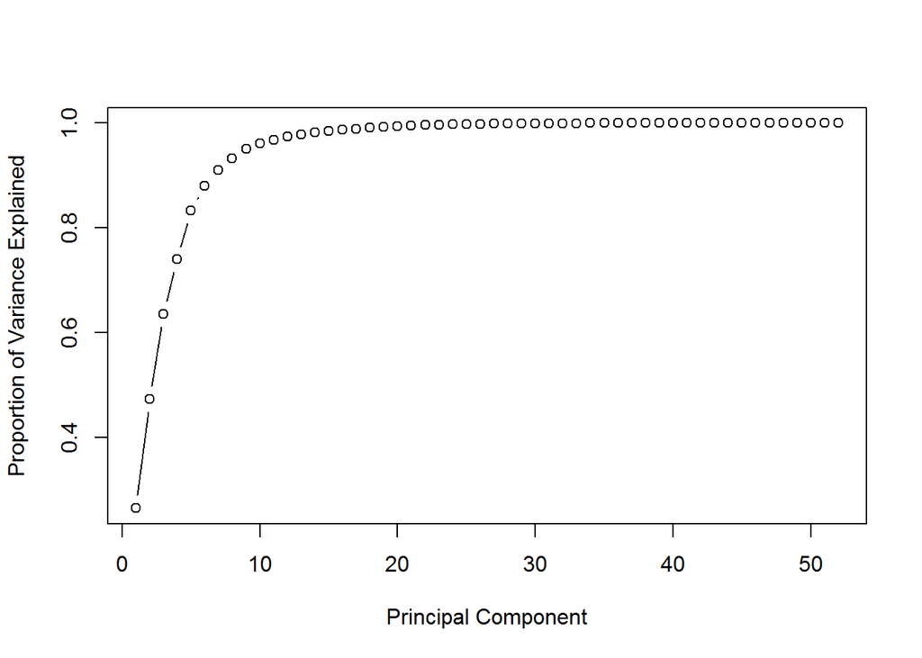

```r
plot(pc_var_com, xlab = "Principal Component", ylab = "Proportion of Variance Explained", type = "b")
```

```r
library(dplyr)
train_pca <- data.frame(pca$x) %>% select(PC1:PC10)
valdation_pca <- data.frame(predict(pca , dummy.data.frame(validation[,-53], sep = "."))) %>% select(PC1:PC10)
```

before we start fitting the models, we may also want to preprocess the testing data, so we will remove the unnecessary columns and reduce the dimensionality using the pca model

```r
colnames <- colnames(train_data[ , -53])
test_pca <- data.frame(predict(pca , dummy.data.frame(test_data[ , colnames], sep = "."))) %>% select(PC1:PC10)
```

now that we have our train, validatio and test data ready we will start fitting the models ## fitting the models : now we will fit some models using a verity of ML algorithms (random forest , decision tree, gbm ) but first let’s load some libraries and prepare the train.control object so we will be using the parallel an doParallel libraries to improve the computation time by pralallizing the calculation on the computer thread, this technique helped a lot in reducing the trainning time and we will use 4-fold cross validation

```r
library(parallel)
library(doParallel)
train_pca$classe <- factor(train$classe)
train.control <- trainControl(method = "cv", number = 4 , allowParallel = TRUE)
```

so let’s start by fitting a random forest classifier

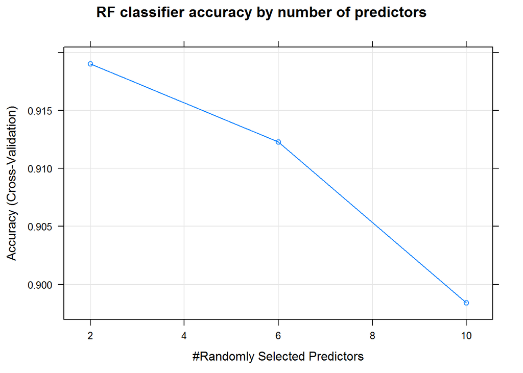

```r
cluster <- makeCluster(detectCores() - 1)
registerDoParallel(cluster)

rf_model <- train(classe ~ . , data = train_pca , method = "rf" , na.action = na.pass , trControl = train.control)
stopCluster(cluster)
registerDoSEQ()
plot(rf_model , main = "RF classifier accuracy by number of predictors")
```

now we will check the performance of the model

```r
rf_model
```

```
## Random Forest
##
## 12757 samples
##    10 predictor
##     5 classes: 'A', 'B', 'C', 'D', 'E'
##
## No pre-processing
## Resampling: Cross-Validated (4 fold)
## Summary of sample sizes: 9567, 9568, 9568, 9568
## Resampling results across tuning parameters:
##
##   mtry  Accuracy   Kappa
##    2    0.9190247  0.8974593
##    6    0.9122832  0.8888843
##   10    0.8984087  0.8713222
##
## Accuracy was used to select the optimal model using the largest value.
## The final value used for the model was mtry = 2.
```

```r
print("***************confusion Matrix ****************")
```

```
## [1] "***************confusion Matrix ****************"
```

```r
confusionMatrix(factor(validation$classe) ,predict(rf_model ,newdata =  valdation_pca))
```

```
## Confusion Matrix and Statistics
##
##           Reference
## Prediction    A    B    C    D    E
##          A 1892   10   17   29    5
##          B   49 1215   30   19   15
##          C   21   22 1129   14   11
##          D   29   14   44 1031    7
##          E   14   47   21   31 1149
##
## Overall Statistics
##
##                Accuracy : 0.9346
##                  95% CI : (0.9285, 0.9403)
##     No Information Rate : 0.2921
##     P-Value [Acc > NIR] : < 2.2e-16
##
##                   Kappa : 0.9172
##
##  Mcnemar's Test P-Value : 1.436e-13
##
## Statistics by Class:
##
##                      Class: A Class: B Class: C Class: D Class: E
## Sensitivity            0.9436   0.9289   0.9098   0.9173   0.9680
## Specificity            0.9874   0.9797   0.9879   0.9836   0.9801
## Pos Pred Value         0.9688   0.9149   0.9432   0.9164   0.9105
## Neg Pred Value         0.9770   0.9832   0.9802   0.9838   0.9932
## Prevalence             0.2921   0.1905   0.1808   0.1637   0.1729
## Detection Rate         0.2756   0.1770   0.1645   0.1502   0.1674
## Detection Prevalence   0.2845   0.1934   0.1744   0.1639   0.1838
## Balanced Accuracy      0.9655   0.9543   0.9488   0.9504   0.9740
```

now let’s fit a decision tree model

```r
dt_model <- train(classe ~ . , data = train_pca , method = "rpart"  , na.action = na.pass)
dt_model
```

```
## CART
##
## 12757 samples
##    10 predictor
##     5 classes: 'A', 'B', 'C', 'D', 'E'
##
## No pre-processing
## Resampling: Bootstrapped (25 reps)
## Summary of sample sizes: 12757, 12757, 12757, 12757, 12757, 12757, ...
## Resampling results across tuning parameters:
##
##   cp          Accuracy   Kappa
##   0.01128149  0.4450577  0.29223049
##   0.01243154  0.4335489  0.27568768
##   0.10098576  0.3239289  0.06350044
##
## Accuracy was used to select the optimal model using the largest value.
## The final value used for the model was cp = 0.01128149.
```

```r
print("***************confusion Matrix ****************")
```

```
## [1] "***************confusion Matrix ****************"
```

```r
confusionMatrix(factor(validation$classe) ,predict(dt_model ,newdata =  valdation_pca))
```

```
## Confusion Matrix and Statistics
##
##           Reference
## Prediction    A    B    C    D    E
##          A 1425   81   87  360    0
##          B  269  690  149  220    0
##          C  519  157  311  210    0
##          D  219  236   89  581    0
##          E  266  531  174  291    0
##
## Overall Statistics
##
##                Accuracy : 0.438
##                  95% CI : (0.4262, 0.4499)
##     No Information Rate : 0.393
##     P-Value [Acc > NIR] : 1.743e-14
##
##                   Kappa : 0.2797
##
##  Mcnemar's Test P-Value : < 2.2e-16
##
## Statistics by Class:
##
##                      Class: A Class: B Class: C Class: D Class: E
## Sensitivity            0.5282   0.4071   0.3840  0.34958       NA
## Specificity            0.8733   0.8766   0.8537  0.89544   0.8162
## Pos Pred Value         0.7296   0.5196   0.2598  0.51644       NA
## Neg Pred Value         0.7408   0.8185   0.9120  0.81167       NA
## Prevalence             0.3930   0.2469   0.1180  0.24210   0.0000
## Detection Rate         0.2076   0.1005   0.0453  0.08463   0.0000
## Detection Prevalence   0.2845   0.1934   0.1744  0.16387   0.1838
## Balanced Accuracy      0.7007   0.6418   0.6188  0.62251       NA
```

the last classifier that we are gonna fit is the gbm classifier, and we will use the parallel computation to speed up the trainning process

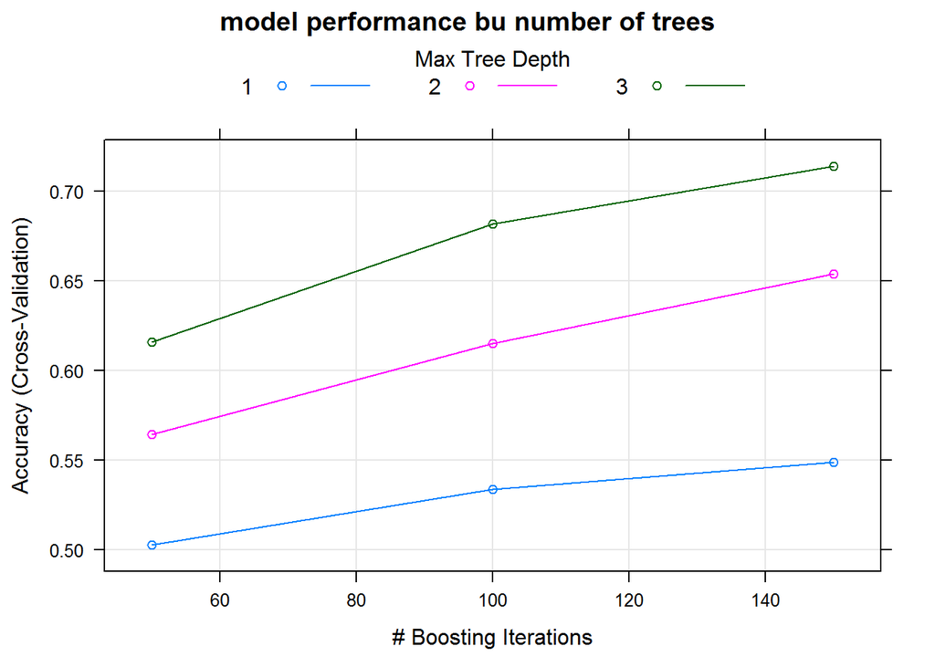

```r
cluster <- makeCluster(detectCores() - 1)
registerDoParallel(cluster)

gbm_model <- train(classe ~ . , data = train_pca , method = "gbm"  , na.action = na.pass , verbos = FALSE , trControl = train.control)
stopCluster(cluster)
registerDoSEQ()
plot(gbm_model , main= "model performance bu number of trees")
```

let’s check the performance of our final model

```r
gbm_model
```

```
## Stochastic Gradient Boosting
##
## 12757 samples
##    10 predictor
##     5 classes: 'A', 'B', 'C', 'D', 'E'
##
## No pre-processing
## Resampling: Cross-Validated (4 fold)
## Summary of sample sizes: 9568, 9568, 9568, 9567
## Resampling results across tuning parameters:
##
##   interaction.depth  n.trees  Accuracy   Kappa
##   1                   50      0.5026262  0.3619952
##   1                  100      0.5336680  0.4041453
##   1                  150      0.5488754  0.4248494
##   2                   50      0.5642395  0.4443432
##   2                  100      0.6149572  0.5103118
##   2                  150      0.6539948  0.5605480
##   3                   50      0.6158973  0.5109633
##   3                  100      0.6819787  0.5957846
##   3                  150      0.7141965  0.6371125
##
## Tuning parameter 'shrinkage' was held constant at a value of 0.1
##
## Tuning parameter 'n.minobsinnode' was held constant at a value of 10
## Accuracy was used to select the optimal model using the largest value.
## The final values used for the model were n.trees = 150, interaction.depth =
##  3, shrinkage = 0.1 and n.minobsinnode = 10.
```

```r
print("***************confusion Matrix ****************")
```

```
## [1] "***************confusion Matrix ****************"
```

```r
confusionMatrix(factor(validation$classe) ,predict(gbm_model ,newdata =  valdation_pca))
```

```
## Confusion Matrix and Statistics
##
##           Reference
## Prediction    A    B    C    D    E
##          A 1695   42   62  128   26
##          B  165  876  130   66   91
##          C  141   76  881   53   46
##          D  107   37  146  789   46
##          E   81  158  110  161  752
##
## Overall Statistics
##
##                Accuracy : 0.7273
##                  95% CI : (0.7166, 0.7378)
##     No Information Rate : 0.3189
##     P-Value [Acc > NIR] : < 2.2e-16
##
##                   Kappa : 0.6538
##
##  Mcnemar's Test P-Value : < 2.2e-16
##
## Statistics by Class:
##
##                      Class: A Class: B Class: C Class: D Class: E
## Sensitivity            0.7743   0.7368   0.6629   0.6591   0.7825
## Specificity            0.9448   0.9204   0.9429   0.9407   0.9136
## Pos Pred Value         0.8679   0.6596   0.7360   0.7013   0.5959
## Neg Pred Value         0.8994   0.9435   0.9210   0.9289   0.9627
## Prevalence             0.3189   0.1732   0.1936   0.1744   0.1400
## Detection Rate         0.2469   0.1276   0.1283   0.1149   0.1095
## Detection Prevalence   0.2845   0.1934   0.1744   0.1639   0.1838
## Balanced Accuracy      0.8596   0.8286   0.8029   0.7999   0.8481
```

## model selection :

after fitig all this models we can say that the best model that give the best accuracy score is the random forest classifier so we will use it as our final model to predict the class for the testing dataset

```r
test_prediction <- predict(rf_model , newdata = test_pca)
```